# ANALISE_PERILPROFISSIONAL

### Projeto Analise de dados

Foi disponilizado um formulado google forms com 23 perguntas, com perguntas pessoais e relevantes ao mercado de trabalho. O objetivo é respoder algumas perguntas.

o principal objetivo geral desta analise, é verficar com base nas respasta, como anda o mercado de trabalho, de acordo faixa etaria de idade e escolaridade.

Perguntas para chegar no objetivo geral:

Qual a faixa salario por idade e escolaridade?

Se a ansiedade esta atrapalhando no dia-a-dia do trabalho?

Qual os principais motivos que leva as pessoas sair, entrar ou mudar de emprego?

Qual a expectativa salarial por idade e esolaridade?

Se a amostra esta contente com o salario ofertado em seu emprego atual, se esta justo ou não sobre sua demada no cenario de trabalho.

Se estar ou não facil a mudança ou recolocação profissional no merdado de trabalho

Qual o tempo ou facilidade esses profissionais estão ficando ou mudando de emprego / trabalho.

Classificação do seu "eu" profissonal ligado ao lider, tempo de deslocação, conformidade com salario, expectativa salarial.

### Resumo

com tudo apos essas analise pode-se ter uma analise sobre o merdado de trabalho relacionado com o 'eu profissional'

link formulario: https://docs.google.com/forms/d/e/1FAIpQLSeCN1W_4F2EG9nHzv1yl-TKqWIB9Fp_ri-BnjV7nGz32DCKaA/viewform?usp=sf_link

### Importar bibliotecas

```python
import pandas as pd
import numpy as np
import matplotlib.pyplot as plt
from PIL import Image
from wordcloud import WordCloud, STOPWORDS, ImageColorGenerator
import plotly.express as px
import seaborn as sns   # biblioteca de graficos
import matplotlib.pyplot as plt    # biblioteca de graficos
```

#### Carregar, tratar e visualizar base de dados

```python
# Carregar base de dados
df = pd.read_excel(r'C:\Users\Samsung\Desktop\TREINAMENTO\formulario google\Pesquisa sobre Mercado de trabalho  (respostas).xlsx')

# tratar base de dados

df = df.rename(columns={'Qual a sua idade?': 'Idade', 'Qual estado você trabalha?': 'Estado',
                        'Como você chega até seu local de trabalho?': 'Meio_tranporte',
                        'Quanto tempo em média leva para chegar até o local de trabalho?': 'Tempo_Deslocamento',
                       'Qual sua renda mensal?': 'Renda_mensal', 'Qual sua expectativa de salário para daqui a 5 anos?': 'Expectativa_salarial',
                       'Você possui outra fonte de renda além de seu trabalho?	': 'Renda_extra', 'Vocé é ansioso (a) ?': 'Ansioso',
                       'Se sim, isso te afeta no dia a dia de trabalho?': 'Ansiendade_afeta', 'Você acredita que o lider/gestor afeta seu desenvolvimento e desempenho?':
                       'Desempelho_lider', 'Você se considera um profissional com autonomia?\n\nUma pessoa autônoma no trabalho é aquela que tem certa liberdade para agir onde trabalha. Isso não significa que só faça o que quer e quando quer, mas que pode cumprir suas tarefas de acordo com a sua autogestão.':
                       'autonomo', 'Você  se considera   um  profissional  generalista ou especialista?\n\nO profissional generalista domina diversos assuntos dentro de várias áreas de atuação. Já o especialista domina tudo sobre uma área específica de atuação': 'Classificacão',
                       'Qual o tempo máximo que já ficou em um emprego/trabalho?': 'Tempo_carteira', 'Nos dias atuais, acredita ser fácil trocar de emprego?': 'Faci_relocacao', 'Qual sua área de atuação?\nExempo:  Com uma palavra como:  Logistica, Vendas, Limpeza,  Administração , TI entre outras...':
                       'Area', 'Você possui outra fonte de renda além de seu trabalho?': 'Renda_extra', 'Acredita ganhar o suficiente no emprego/trabalho atual?\n\n trabalho está ligado a objetivos e realizações profissionais, emprego é simplesmente uma forma de conseguir renda':
                       'Conformidade_salario', 'Procura buscar conhecimento extra para que seus objetivos profissionais sejam alcançados?': 'atv_extra', 'Com palavras chaves, oque te motivou sair do último emprego?\nExempo: gestão desqualificada, exploração, remuneração entre outras':
                       'mud_emprego', 'O que te motiva entrar em uma empresa?': 'Motiv_entrar', 'O que te motiva sair em uma empresa?': 'Motiv_sair', 'Qual seu nível de maior escolaridade concluída?':'Escolaridade', 'Quantas vezes ja mudou de emprego?': 'Mudanca_emprego'})



# tratar string

df["Expectativa_salarial"] = df["Expectativa_salarial"].astype(int)
df.Renda_mensal = df.Renda_mensal.replace('Entre R$ 2.000,00 a R$ 4000,00', 'Entre R$ 2.001,00 a R$ 4000,00')
df.loc[df.Ansioso == 'Não', ['Ansiendade_afeta']] = 'Não sou ansioso'
df.loc[(df.Ansiendade_afeta == 'Não sou ansioso') & (df.Ansioso == 'Sim'), ['Ansiendade_afeta']] = 'Não'
df.Area = df.Area.str.strip()
df.Escolaridade = df.Escolaridade.str.strip()
df.loc[(df.Escolaridade == 'Superior incompleto') | (df.Escolaridade == 'Ensino superior incompleto') | (df.Escolaridade == 'Superior incompleto') | (df.Escolaridade == 'Ensino superior incompleto') | (df.Escolaridade == 'Estou cursando o ensino superior')  | (df.Escolaridade == 'Ensino superior incompleto'), ['Escolaridade']] = 'Ensino Médio'
df.loc[(df.Meio_tranporte == 'Remoto'), ['Meio_tranporte']] = 'home office'
df = df.drop(columns=['Carimbo de data/hora', 'Endereço de e-mail'])
df.head(5)
```

|  | Idade | Estado | Meio_tranporte | Tempo_Deslocamento | Area | Renda_mensal | Expectativa_salarial | Renda_extra | Conformidade_salario | Ansioso | ... | Escolaridade | Motiv_entrar | Motiv_sair | mud_emprego | Faci_relocacao | Mudanca_emprego | Tempo_carteira | Classificacão | autonomo | Desempelho_lider |
| --- | --- | --- | --- | --- | --- | --- | --- | --- | --- | --- | --- | --- | --- | --- | --- | --- | --- | --- | --- | --- | --- |
| 0 | Entre 19 a 25 anos | GO | Condução própria | home office | Licenciatura | Estou desempregado | 7000 | Sim | Estou desempregado | Sim | ... | Ensino Médio | Salário, Inclusão, Valores, Beneficios | Salário, Propósito, Falta de reconhecimento, E... | Nunca trabalhei | Não | Até 3 vezes | Menos de 6 meses | Generalista | Sim | Sim |
| 1 | Entre 26 a 30 anos | GO | Transporte da empresa | Meia hora | Outras | Menos de R$ 1.500,00 | 8000 | Não | Não | Sim | ... | Ensino Superior | Salário, Perspectivas de carreira | Falta de reconhecimento | Gestão desqualificada | Não | De 4 a 8 vezes | Entre 12 meses a 24 meses | Generalista | Não | Sim |
| 2 | Entre 31 a 40 anos | GO | Condução própria | Meia hora | Vendas | Entre R$ 1.500,00 e R$ 2.000,00 | 2500 | Não | Sim | Sim | ... | Ensino Médio | Perspectivas de carreira | Valores | Gestão desqualificado | Não | Até 3 vezes | Entre 12 meses a 24 meses | Especialista | Sim | Em partes |
| 3 | Entre 19 a 25 anos | GO | Transporte da empresa | Meia hora | Alimentos | Menos de R$ 1.500,00 | 2500 | Não | Não | Sim | ... | Ensino Médio | Salário, Perspectivas de carreira, Beneficios | Falta de reconhecimento, Exploração de mão de ... | Outra proposta | Não | Até 3 vezes | Entre 6 a 12 meses | Generalista | Talvez | Em partes |
| 4 | Entre 31 a 40 anos | GO | Condução própria | Meia hora | Entregadora | Menos de R$ 1.500,00 | 5000 | Não | Não | Sim | ... | Ensino Médio | Beneficios | Desvio de função, Falta de reconhecimento, Exp... | Pandemia | Não | De 4 a 8 vezes | Mais de 36 meses | Generalista | Não | Sim |

5 rows × 22 columns

```python
# verificar informações
N_pesquisa = len(df.Idade)
df.info()
```

```
<class 'pandas.core.frame.DataFrame'>
RangeIndex: 61 entries, 0 to 60
Data columns (total 22 columns):
 #   Column                Non-Null Count  Dtype
---  ------                --------------  -----
 0   Idade                 61 non-null     object
 1   Estado                61 non-null     object
 2   Meio_tranporte        61 non-null     object
 3   Tempo_Deslocamento    61 non-null     object
 4   Area                  61 non-null     object
 5   Renda_mensal          61 non-null     object
 6   Expectativa_salarial  61 non-null     int32
 7   Renda_extra           61 non-null     object
 8   Conformidade_salario  61 non-null     object
 9   Ansioso               61 non-null     object
 10  Ansiendade_afeta      61 non-null     object
 11  atv_extra             61 non-null     object
 12  Escolaridade          61 non-null     object
 13  Motiv_entrar          61 non-null     object
 14  Motiv_sair            61 non-null     object
 15  mud_emprego           61 non-null     object
 16  Faci_relocacao        61 non-null     object
 17  Mudanca_emprego       61 non-null     object
 18  Tempo_carteira        61 non-null     object
 19  Classificacão         61 non-null     object
 20  autonomo              61 non-null     object
 21  Desempelho_lider      61 non-null     object
dtypes: int32(1), object(21)
memory usage: 10.4+ KB
```

```python
df.Renda_mensal.value_counts()
```

```
Menos de R$ 1.500,00                22
Entre R$ 1.500,00 e R$ 2.000,00     15
Entre R$ 2.001,00 a R$ 4000,00      14
Estou desempregado                   5
Entre R$ 4.001,00 a R$ 10.000,00     5
Name: Renda_mensal, dtype: int64
```

### Analise estatíticas

```python
# DADOS estatístico string object
df.select_dtypes('object').describe().transpose()
```

|  | count | unique | top | freq |
| --- | --- | --- | --- | --- |
| Idade | 61 | 5 | Entre 19 a 25 anos | 30 |
| Estado | 61 | 6 | GO | 55 |
| Meio_tranporte | 61 | 5 | Condução própria | 40 |
| Tempo_Deslocamento | 61 | 5 | Meia hora | 47 |
| Area | 61 | 49 | Vendas | 9 |
| Renda_mensal | 61 | 5 | Menos de R$ 1.500,00 | 22 |
| Renda_extra | 61 | 2 | Não | 46 |
| Conformidade_salario | 61 | 3 | Não | 36 |
| Ansioso | 61 | 2 | Sim | 53 |
| Ansiendade_afeta | 61 | 3 | Sim | 38 |
| atv_extra | 61 | 2 | Sim | 58 |
| Escolaridade | 61 | 6 | Ensino Médio | 29 |
| Motiv_entrar | 61 | 28 | Perspectivas de carreira | 13 |
| Motiv_sair | 61 | 33 | Falta de reconhecimento | 11 |
| mud_emprego | 61 | 47 | Remuneração | 8 |
| Faci_relocacao | 61 | 2 | Não | 50 |
| Mudanca_emprego | 61 | 3 | Até 3 vezes | 45 |
| Tempo_carteira | 61 | 5 | Mais de 36 meses | 29 |
| Classificacão | 61 | 2 | Generalista | 44 |
| autonomo | 61 | 3 | Sim | 40 |
| Desempelho_lider | 61 | 3 | Sim | 31 |

### Resumo da base de dados

```python
# contagem e analise exploratoria de dados

print("faixa etária de idade das amostras")
print(df.Idade.value_counts(normalize=True).map("{:.1%}".format))
print("-"*60)
print("contar numero de Estado onde as amostras trabalham ")
print(df.Estado.value_counts(normalize=True).map("{:.1%}".format))
print("-"*60)
print("Meio de transporte que as amostras usa para ir trabalhar")
print(df.Meio_tranporte.value_counts(normalize=True).map("{:.1%}".format))
print("-"*60)
print("Tempo de deslocamento que as amostra usa para irem trabalhar")
print(df.Tempo_Deslocamento.value_counts(normalize=True).map("{:.1%}".format))
print("-"*60)
print("Area de atuação das amostras")
print(df.Area.value_counts(normalize=True).map("{:.1%}".format))
print("-"*60)
print("Faixa salarial das amostras")
print(df.Renda_mensal.value_counts(normalize=True).map("{:.1%}".format))
print("-"*60)
print("Faixa de expectativa salarial após 5 anos")
print(df.Expectativa_salarial.value_counts(normalize=True).map("{:.1%}".format))
print("-"*60)
print("Número de amostra que cotém renda extra")
print(df.Renda_extra.value_counts(normalize=True).map("{:.1%}".format))
print("-"*60)
print("Número de amostra que acredita receber o salario suficiente")
print(df.Conformidade_salario.value_counts(normalize=True).map("{:.1%}".format))
print("-"*60)
print("Número de amostra que são ansiosos")
print(df.Ansioso.value_counts(normalize=True).map("{:.1%}".format))
print("-"*60)
print("Número de amostra que são afetada pela ansiendade")
print(df.Ansiendade_afeta.value_counts(normalize=True).map("{:.1%}".format))
print("-"*60)
print("Número de amostra que buscam aprimorar conhecimento")
print(df.atv_extra.value_counts(normalize=True).map("{:.1%}".format))
print("-"*60)
print("Grau de escoladirade das amostra")
print(df.Escolaridade.value_counts(normalize=True).map("{:.1%}".format))
print("-"*60)
print("Numero de amostra que acreditar sobre facilidade de relocação de emprego")
print(df.Faci_relocacao .value_counts(normalize=True).map("{:.1%}".format))
print("-"*60)
print("Numero de vez que a amostra mudou de emprego")
print(df.Mudanca_emprego.value_counts(normalize=True).map("{:.1%}".format))
print("-"*60)
print("Tempo de casa das amostra")
print(df.Tempo_carteira.value_counts(normalize=True).map("{:.1%}".format))
print("-"*60)
print("Classificação da amostra")
print(df.Classificacão.value_counts(normalize=True).map("{:.1%}".format))
print("-"*60)
print("Numero de funcionario autonomo")
print(df.autonomo.value_counts(normalize=True).map("{:.1%}".format))
print("-"*60)
print("Numero sobre desemprenho afetado pela liderança")
print(df.Desempelho_lider.value_counts(normalize=True).map("{:.1%}".format))
```

```
faixa etária de idade das amostras
Entre 19 a 25 anos    49.2%
Entre 26 a 30 anos    24.6%
Entre 31 a 40 anos    19.7%
+ 41 anos              4.9%
Entre 16 a 18 anos     1.6%
Name: Idade, dtype: object
------------------------------------------------------------
contar numero de Estado onde as amostras trabalham
GO    90.2%
MG     3.3%
CE     1.6%
SC     1.6%
SP     1.6%
Df     1.6%
Name: Estado, dtype: object
------------------------------------------------------------
Meio de transporte que as amostras usa para ir trabalhar
Condução própria         65.6%
Andando                  16.4%
Transporte da empresa    13.1%
home office               3.3%
Transporte público        1.6%
Name: Meio_tranporte, dtype: object
------------------------------------------------------------
Tempo de deslocamento que as amostra usa para irem trabalhar
Meia hora             77.0%
Uma hora              13.1%
home office            6.6%
Mais de duas horas     1.6%
Uma hora e meia        1.6%
Name: Tempo_Deslocamento, dtype: object
------------------------------------------------------------
Area de atuação das amostras
Vendas                     14.8%
administração               3.3%
Financeiro                  3.3%
Limpeza                     3.3%
RH                          3.3%
Emplacamento                1.6%
```

[output cut: 132 more lines]

```
Generalista     72.1%
Especialista    27.9%
Name: Classificacão, dtype: object
------------------------------------------------------------
Numero de funcionario autonomo
Sim       65.6%
Talvez    18.0%
Não       16.4%
Name: autonomo, dtype: object
------------------------------------------------------------
Numero sobre desemprenho afetado pela liderança
Sim          50.8%
Em partes    32.8%
Não          16.4%
Name: Desempelho_lider, dtype: object
```

### biblioteca de funções:

```python
def wordtex(coluna):
    text = list(coluna)
    text = " ".join(a for a in text)

    # lista de stopword
    stopwords = set(STOPWORDS)
    stopwords.update(["da", "meu", "em", "você", "de", "ao", "os", "falta"])

    # gerar uma wordcloud
    wordcloud = WordCloud(stopwords=stopwords,
                          background_color="black",
                          width=1600, height=800).generate(text)
    # mostrar a imagem final
    fig, ax = plt.subplots(figsize=(10,6))
    ax.imshow(wordcloud, interpolation='bilinear')
    ax.set_axis_off()

    plt.imshow(wordcloud);
    wordcloud.to_file("airbnb_summary_wordcloud.png")

    # definir função para diagrama de caixa
def diagrama_cx(coluna):
    fig, (ax1, ax2) = plt.subplots(1, 2)     # configuração do grafico
    fig.set_size_inches(15, 5)              # configuração do grafico
    sns.boxplot(x=coluna, ax=ax1)
    ax2.set_xlim(limites(coluna))
    sns.boxplot(x=coluna, ax=ax2)

# definir função para histrograma
def histrograma(coluna):
    plt.figure(figsize=(15,5))                     # configuração do grafico
    sns.histplot(coluna, bins=50,  kde=True)     # grafico hitrograma

    # definir limite para colunas
def limites(coluna):
    q1 = coluna.quantile(0.25)
    q3 = coluna.quantile(0.75)
    amplitude = q3 - q1
    return q1 - 1.5 * amplitude, q3 + 1.5 *amplitude

# definir função para excluir outliers
def excluir_outliers(base_d_dados, nome_coluna):
    qtd_linha = base_d_dados.shape[0]
    lim_inf, lim_sup = limites(base_d_dados[nome_coluna])
    base_d_dados = base_d_dados.loc[(base_d_dados[nome_coluna] >= lim_inf) & (base_d_dados[nome_coluna] <= lim_sup), :]
    linhas_removidas = qtd_linha - base_d_dados.shape[0]
    return base_d_dados, linhas_removidas

def grafico_barra(coluna):
    plt.figure(figsize=(15, 5))
    ax = sns.barplot(x=coluna.value_counts().index, y=coluna.value_counts())
    ax.set_xlim(limites(coluna))

def valuecout (tabela, coluna):
    print(f" total {len(tabela[coluna])}")
    print(tabela[coluna].value_counts())
    print('%'*60)
    print(tabela[coluna].value_counts(normalize=True).map("{:.1%}".format))
    print('-'*60)
```

### Qual os principais motivos que leva as pessoas sair, entrar ou mudar de emprego?

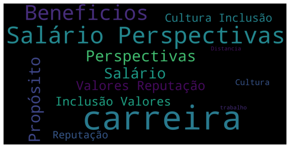

```python
# nuvem de palavra para analisar os principais motivos para entrar em uma empresa
# obs: quanto maior a palavra mais vezes a palavra foi escrita
wordtex(df.Motiv_entrar)
```

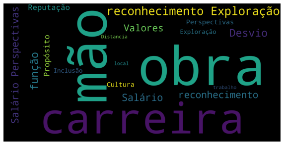

```python
# nuvem de palavra para analisar os principais motivos para sair em uma empresa
wordtex(df.Motiv_sair)
```

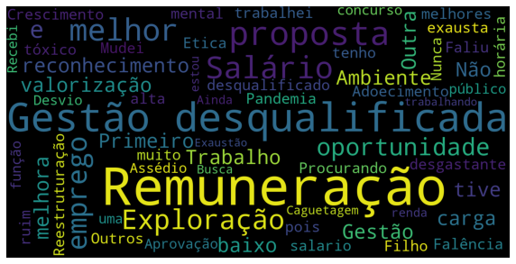

```python
# nuvem de palavra para analisar os principais que levaram mudar de emprego
wordtex(df.mud_emprego)
```

### Area / cargo de atuação da amostra

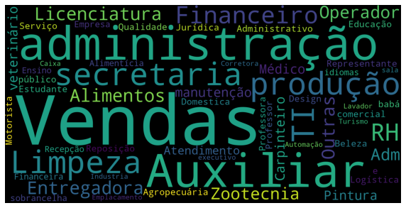

```python
# nuvem de palavra para analisar area de atuação
wordtex(df.Area)
```

### Qual a faixa salario por idade e escolaridade?

```python
df2 = pd.DataFrame()
df2['escolaridade'] = df.Escolaridade
df2["faixa_idade"] = df.Idade
df2['faixa_salarial'] = df.Renda_mensal
df2['renda_extra'] = df.Renda_extra
df2["espectativa"] = df.Expectativa_salarial
df2
```

|  | escolaridade | faixa_idade | faixa_salarial | renda_extra | espectativa |
| --- | --- | --- | --- | --- | --- |
| 0 | Ensino Médio | Entre 19 a 25 anos | Estou desempregado | Sim | 7000 |
| 1 | Ensino Superior | Entre 26 a 30 anos | Menos de R$ 1.500,00 | Não | 8000 |
| 2 | Ensino Médio | Entre 31 a 40 anos | Entre R$ 1.500,00 e R$ 2.000,00 | Não | 2500 |
| 3 | Ensino Médio | Entre 19 a 25 anos | Menos de R$ 1.500,00 | Não | 2500 |
| 4 | Ensino Médio | Entre 31 a 40 anos | Menos de R$ 1.500,00 | Não | 5000 |
| ... | ... | ... | ... | ... | ... |
| 56 | Ensino Superior | Entre 19 a 25 anos | Menos de R$ 1.500,00 | Sim | 5000 |
| 57 | Ensino Técnico | Entre 31 a 40 anos | Menos de R$ 1.500,00 | Sim | 6000 |
| 58 | Ensino Técnico | Entre 26 a 30 anos | Entre R$ 1.500,00 e R$ 2.000,00 | Não | 4500 |
| 59 | Ensino Superior | Entre 26 a 30 anos | Entre R$ 1.500,00 e R$ 2.000,00 | Não | 10000 |
| 60 | Ensino Médio | Entre 26 a 30 anos | Menos de R$ 1.500,00 | Não | 3000 |

61 rows × 5 columns

```python
# Analisa faixa de idade, salarial e de renda extra em relação a faixa etaria do ensino medio
em = df2.loc[df2.escolaridade == 'Ensino Médio']
valuecout(em, 'faixa_idade')
valuecout(em, 'faixa_salarial')
valuecout(em, 'renda_extra')
```

```
 total 29
Entre 19 a 25 anos    16
Entre 26 a 30 anos     6
Entre 31 a 40 anos     5
+ 41 anos              1
Entre 16 a 18 anos     1
Name: faixa_idade, dtype: int64
%%%%%%%%%%%%%%%%%%%%%%%%%%%%%%%%%%%%%%%%%%%%%%%%%%%%%%%%%%%%
Entre 19 a 25 anos    55.2%
Entre 26 a 30 anos    20.7%
Entre 31 a 40 anos    17.2%
+ 41 anos              3.4%
Entre 16 a 18 anos     3.4%
Name: faixa_idade, dtype: object
------------------------------------------------------------
 total 29
Menos de R$ 1.500,00               13
Entre R$ 1.500,00 e R$ 2.000,00     9
Entre R$ 2.001,00 a R$ 4000,00      4
Estou desempregado                  3
Name: faixa_salarial, dtype: int64
%%%%%%%%%%%%%%%%%%%%%%%%%%%%%%%%%%%%%%%%%%%%%%%%%%%%%%%%%%%%
Menos de R$ 1.500,00               44.8%
Entre R$ 1.500,00 e R$ 2.000,00    31.0%
Entre R$ 2.001,00 a R$ 4000,00     13.8%
Estou desempregado                 10.3%
Name: faixa_salarial, dtype: object
------------------------------------------------------------
 total 29
Não    23
Sim     6
Name: renda_extra, dtype: int64
%%%%%%%%%%%%%%%%%%%%%%%%%%%%%%%%%%%%%%%%%%%%%%%%%%%%%%%%%%%%
Não    79.3%
Sim    20.7%
Name: renda_extra, dtype: object
------------------------------------------------------------
```

```python
# Analisa faixa de idade, salarial e de renda extra em relação a faixa etaria do Ensino Técnico
et = df2.loc[df2.escolaridade == 'Ensino Técnico']
valuecout(et, 'faixa_idade')
valuecout(et, 'faixa_salarial')
valuecout(et, 'renda_extra')
```

```
 total 9
Entre 19 a 25 anos    6
Entre 31 a 40 anos    2
Entre 26 a 30 anos    1
Name: faixa_idade, dtype: int64
%%%%%%%%%%%%%%%%%%%%%%%%%%%%%%%%%%%%%%%%%%%%%%%%%%%%%%%%%%%%
Entre 19 a 25 anos    66.7%
Entre 31 a 40 anos    22.2%
Entre 26 a 30 anos    11.1%
Name: faixa_idade, dtype: object
------------------------------------------------------------
 total 9
Menos de R$ 1.500,00               5
Entre R$ 1.500,00 e R$ 2.000,00    2
Estou desempregado                 1
Entre R$ 2.001,00 a R$ 4000,00     1
Name: faixa_salarial, dtype: int64
%%%%%%%%%%%%%%%%%%%%%%%%%%%%%%%%%%%%%%%%%%%%%%%%%%%%%%%%%%%%
Menos de R$ 1.500,00               55.6%
Entre R$ 1.500,00 e R$ 2.000,00    22.2%
Estou desempregado                 11.1%
Entre R$ 2.001,00 a R$ 4000,00     11.1%
Name: faixa_salarial, dtype: object
------------------------------------------------------------
 total 9
Não    5
Sim    4
Name: renda_extra, dtype: int64
%%%%%%%%%%%%%%%%%%%%%%%%%%%%%%%%%%%%%%%%%%%%%%%%%%%%%%%%%%%%
Não    55.6%
Sim    44.4%
Name: renda_extra, dtype: object
------------------------------------------------------------
```

```python
# Analisa faixa de idade, salarial e de renda extra em relação a faixa etaria do Ensino Superior
es = df2.loc[df2.escolaridade == 'Ensino Superior']
valuecout(es, 'faixa_idade')
valuecout(es, 'faixa_salarial')
valuecout(es, 'renda_extra')
```

```
 total 17
Entre 19 a 25 anos    8
Entre 26 a 30 anos    6
Entre 31 a 40 anos    3
Name: faixa_idade, dtype: int64
%%%%%%%%%%%%%%%%%%%%%%%%%%%%%%%%%%%%%%%%%%%%%%%%%%%%%%%%%%%%
Entre 19 a 25 anos    47.1%
Entre 26 a 30 anos    35.3%
Entre 31 a 40 anos    17.6%
Name: faixa_idade, dtype: object
------------------------------------------------------------
 total 17
Entre R$ 2.001,00 a R$ 4000,00      8
Entre R$ 1.500,00 e R$ 2.000,00     3
Entre R$ 4.001,00 a R$ 10.000,00    3
Menos de R$ 1.500,00                2
Estou desempregado                  1
Name: faixa_salarial, dtype: int64
%%%%%%%%%%%%%%%%%%%%%%%%%%%%%%%%%%%%%%%%%%%%%%%%%%%%%%%%%%%%
Entre R$ 2.001,00 a R$ 4000,00      47.1%
Entre R$ 1.500,00 e R$ 2.000,00     17.6%
Entre R$ 4.001,00 a R$ 10.000,00    17.6%
Menos de R$ 1.500,00                11.8%
Estou desempregado                   5.9%
Name: faixa_salarial, dtype: object
------------------------------------------------------------
 total 17
Não    13
Sim     4
Name: renda_extra, dtype: int64
%%%%%%%%%%%%%%%%%%%%%%%%%%%%%%%%%%%%%%%%%%%%%%%%%%%%%%%%%%%%
Não    76.5%
Sim    23.5%
Name: renda_extra, dtype: object
------------------------------------------------------------
```

```python
# Analisa faixa de idade, salarial e de renda extra em relação a faixa etaria do Ensino fundamental
ef = df2.loc[df2.escolaridade == 'Ensino fundamental']
valuecout(ef, 'faixa_idade')
valuecout(ef, 'faixa_salarial')
valuecout(ef, 'renda_extra')
```

```
 total 3
Entre 31 a 40 anos    1
+ 41 anos             1
Entre 26 a 30 anos    1
Name: faixa_idade, dtype: int64
%%%%%%%%%%%%%%%%%%%%%%%%%%%%%%%%%%%%%%%%%%%%%%%%%%%%%%%%%%%%
Entre 31 a 40 anos    33.3%
+ 41 anos             33.3%
Entre 26 a 30 anos    33.3%
Name: faixa_idade, dtype: object
------------------------------------------------------------
 total 3
Menos de R$ 1.500,00               2
Entre R$ 1.500,00 e R$ 2.000,00    1
Name: faixa_salarial, dtype: int64
%%%%%%%%%%%%%%%%%%%%%%%%%%%%%%%%%%%%%%%%%%%%%%%%%%%%%%%%%%%%
Menos de R$ 1.500,00               66.7%
Entre R$ 1.500,00 e R$ 2.000,00    33.3%
Name: faixa_salarial, dtype: object
------------------------------------------------------------
 total 3
Não    3
Name: renda_extra, dtype: int64
%%%%%%%%%%%%%%%%%%%%%%%%%%%%%%%%%%%%%%%%%%%%%%%%%%%%%%%%%%%%
Não    100.0%
Name: renda_extra, dtype: object
------------------------------------------------------------
```

```python
# Analisa faixa de idade, salarial e de renda extra em relação a faixa etaria do Mestrado
m = df2.loc[df2.escolaridade == 'Mestrado']
valuecout(m, 'faixa_idade')
valuecout(m, 'faixa_salarial')
valuecout(m, 'renda_extra')
```

```
 total 1
+ 41 anos    1
Name: faixa_idade, dtype: int64
%%%%%%%%%%%%%%%%%%%%%%%%%%%%%%%%%%%%%%%%%%%%%%%%%%%%%%%%%%%%
+ 41 anos    100.0%
Name: faixa_idade, dtype: object
------------------------------------------------------------
 total 1
Entre R$ 4.001,00 a R$ 10.000,00    1
Name: faixa_salarial, dtype: int64
%%%%%%%%%%%%%%%%%%%%%%%%%%%%%%%%%%%%%%%%%%%%%%%%%%%%%%%%%%%%
Entre R$ 4.001,00 a R$ 10.000,00    100.0%
Name: faixa_salarial, dtype: object
------------------------------------------------------------
 total 1
Não    1
Name: renda_extra, dtype: int64
%%%%%%%%%%%%%%%%%%%%%%%%%%%%%%%%%%%%%%%%%%%%%%%%%%%%%%%%%%%%
Não    100.0%
Name: renda_extra, dtype: object
------------------------------------------------------------
```

```python
# Analisa faixa de idade, salarial e de renda extra em relação a faixa etaria do Especialista
m = df2.loc[df2.escolaridade == 'Especialista']
valuecout(m, 'faixa_idade')
valuecout(m, 'faixa_salarial')
valuecout(m, 'renda_extra')
```

```
 total 2
Entre 26 a 30 anos    1
Entre 31 a 40 anos    1
Name: faixa_idade, dtype: int64
%%%%%%%%%%%%%%%%%%%%%%%%%%%%%%%%%%%%%%%%%%%%%%%%%%%%%%%%%%%%
Entre 26 a 30 anos    50.0%
Entre 31 a 40 anos    50.0%
Name: faixa_idade, dtype: object
------------------------------------------------------------
 total 2
Entre R$ 4.001,00 a R$ 10.000,00    1
Entre R$ 2.001,00 a R$ 4000,00      1
Name: faixa_salarial, dtype: int64
%%%%%%%%%%%%%%%%%%%%%%%%%%%%%%%%%%%%%%%%%%%%%%%%%%%%%%%%%%%%
Entre R$ 4.001,00 a R$ 10.000,00    50.0%
Entre R$ 2.001,00 a R$ 4000,00      50.0%
Name: faixa_salarial, dtype: object
------------------------------------------------------------
 total 2
Sim    1
Não    1
Name: renda_extra, dtype: int64
%%%%%%%%%%%%%%%%%%%%%%%%%%%%%%%%%%%%%%%%%%%%%%%%%%%%%%%%%%%%
Sim    50.0%
Não    50.0%
Name: renda_extra, dtype: object
------------------------------------------------------------
```